# HW4 : 석사 2학기 이동규

#### **Library**

```r
library(poLCA) # chapter 2
library(vcd) # chapter 2
library(MatchIt) # chapter 3
library(quantreg) # chapter 3
library(weights) # chapter 3
library(stats4) # chapter 4
library(TSP) # chapter 4
library(mice) # chapter 5
```

### 2장

```r
#data values
data(values)
head(values)
```

```
##   A B C D
## 1 2 2 2 2
## 2 2 2 2 2
## 3 2 2 2 2
## 4 2 2 2 2
## 5 2 2 2 2
## 6 2 2 2 2
```

```r
f <- cbind(A,B,C,D) ~ 1
```

values 데이터를 불러오고, A,B,C,D 변수에 대해 공변량이 없는 함수를 고려한다.

```r
# nclass = 2
set.seed(123)
M2 <- poLCA(f,values,nclass=2)
```

```
## Conditional item response (column) probabilities,
##  by outcome variable, for each class (row)
##
## $A
##            Pr(1)  Pr(2)
## class 1:  0.2864 0.7136
## class 2:  0.0068 0.9932
##
## $B
##            Pr(1)  Pr(2)
## class 1:  0.6704 0.3296
## class 2:  0.0602 0.9398
##
## $C
##            Pr(1)  Pr(2)
## class 1:  0.6460 0.3540
## class 2:  0.0735 0.9265
##
## $D
##            Pr(1)  Pr(2)
## class 1:  0.8676 0.1324
## class 2:  0.2309 0.7691
##
## Estimated class population shares
##  0.7208 0.2792
##
## Predicted class memberships (by modal posterior prob.)
##  0.6713 0.3287
##
## =========================================================
## Fit for 2 latent classes:
## =========================================================
## number of observations: 216
## number of estimated parameters: 9
## residual degrees of freedom: 6
## maximum log-likelihood: -504.4677
##
## AIC(2): 1026.935
## BIC(2): 1057.313
## G^2(2): 2.719922 (Likelihood ratio/deviance statistic)
## X^2(2): 2.719764 (Chi-square goodness of fit)
##
```

각 변수(A,B,C,D)에 대해 가질 수 있는 값들 1,2에 따라 어느 잠재층(class)에 속하는지 확률을 출력한 값이다. 위의 값들은 $\hat{\pi}_{rjk}$ 를 추정한 결과이다. (j는 A,B,C,D , k는 pr(1),pr(2) , r은 class) 또한, 각 class에 대한 사전확률(0.7208, 0.2792) 를 확인할 수 있으며, 사후확률(0.6713,0.3287)도 확인할 수 있다. AIC , BIC 로 모형비교에 대한 지표를 볼 수 있다.

AIC, BIC에 대한 내용은 아래에서 잠재층을 3개로 간주한 모형을 통해서 더 살펴볼 수 있다.

```r
# nclass = 3
set.seed(123)
M3 <- poLCA(f,values,nclass=3,maxiter=10000)
```

```
## Conditional item response (column) probabilities,
##  by outcome variable, for each class (row)
##
## $A
##            Pr(1)  Pr(2)
## class 1:  0.0028 0.9972
## class 2:  0.1653 0.8347
## class 3:  0.5509 0.4491
##
## $B
##            Pr(1)  Pr(2)
## class 1:  0.0236 0.9764
## class 2:  0.5203 0.4797
## class 3:  0.9240 0.0760
##
## $C
##            Pr(1)  Pr(2)
## class 1:  0.0068 0.9932
## class 2:  0.5637 0.4363
## class 3:  0.7369 0.2631
##
## $D
##            Pr(1)  Pr(2)
## class 1:  0.1015 0.8985
## class 2:  0.8074 0.1926
## class 3:  0.9288 0.0712
##
## Estimated class population shares
##  0.2003 0.6037 0.1961
##
## Predicted class memberships (by modal posterior prob.)
##  0.1944 0.6713 0.1343
##
## =========================================================
## Fit for 3 latent classes:
## =========================================================
## number of observations: 216
## number of estimated parameters: 14
## residual degrees of freedom: 1
## maximum log-likelihood: -503.3011
##
## AIC(3): 1034.602
## BIC(3): 1081.856
## G^2(3): 0.3868562 (Likelihood ratio/deviance statistic)
## X^2(3): 0.4225492 (Chi-square goodness of fit)
##
```

class가 2인 AIC, BIC보다 class가 3인 AIC, BIC값이 더 크므로, AIC, BIC값이 작은 값인 class=2 인 모형을 택하기로 한다.

```r
#data election
data(election)
set.seed(1234)
f.1 <- cbind(MORALG,CARESG,KNOWG,LEADG,DISHONG,INTELG,
             MORALB,CARESB,KNOWB,LEADB,DISHONB,INTELB)~PARTY
lcrm.1 <- poLCA(f.1,election,nclass=3,nrep=5)
```

```
## Model 1: llik = -16222.32 ... best llik = -16222.32
## Model 2: llik = -16222.32 ... best llik = -16222.32
## Model 3: llik = -16222.32 ... best llik = -16222.32
## Model 4: llik = -16222.32 ... best llik = -16222.32
## Model 5: llik = -16222.32 ... best llik = -16222.32
## Conditional item response (column) probabilities,
##  by outcome variable, for each class (row)
##
## $MORALG
##           1 Extremely well 2 Quite well 3 Not too well 4 Not well at all
## class 1:            0.6221       0.3350         0.0172            0.0258
## class 2:            0.1373       0.6682         0.1802            0.0143
## class 3:            0.1081       0.3832         0.3038            0.2048
##
## $CARESG
##           1 Extremely well 2 Quite well 3 Not too well 4 Not well at all
## class 1:            0.4858       0.4164         0.0534            0.0444
## class 2:            0.0388       0.6138         0.2886            0.0589
## class 3:            0.0356       0.2281         0.4501            0.2861
##
## $KNOWG
##           1 Extremely well 2 Quite well 3 Not too well 4 Not well at all
## class 1:            0.7189       0.2451         0.0040             0.032
## class 2:            0.0712       0.8173         0.1025             0.009
## class 3:            0.1436       0.5327         0.2556             0.068
##
## $LEADG
##           1 Extremely well 2 Quite well 3 Not too well 4 Not well at all
## class 1:            0.4720       0.4326         0.0643            0.0311
## class 2:            0.0256       0.6280         0.3144            0.0320
## class 3:            0.0278       0.1899         0.5137            0.2685
##
## $DISHONG
##           1 Extremely well 2 Quite well 3 Not too well 4 Not well at all
## class 1:            0.0518       0.0538         0.2890            0.6054
## class 2:            0.0210       0.1412         0.5341            0.3037
## class 3:            0.1876       0.3435         0.3078            0.1611
##
## $INTELG
##           1 Extremely well 2 Quite well 3 Not too well 4 Not well at all
```

[output cut: 53 more lines]

```
## =========================================================
## 3 / 1
##             Coefficient  Std. error  t value  Pr(>|t|)
## (Intercept)    -4.97967     0.32771  -15.195         0
## PARTY           1.36762     0.08081   16.924         0
## =========================================================
## number of observations: 1300
## number of estimated parameters: 112
## residual degrees of freedom: 1188
## maximum log-likelihood: -16222.32
##
## AIC(3): 32668.65
## BIC(3): 33247.7
## X^2(3): 34565233105 (Chi-square goodness of fit)
##
```

이번엔 election data를 보고 살펴보자. 사전확률, 사후확률을 확인할 수 있으며 PARTY라는 공변량을 고려한 채 분석환 결과이다. 결과를보면 잠재층 1대비 2,3에서는 PARTY에 대해 양의부호 이므로 PARTY변수가 공화당으로 갈 수록 favor bush임을 말하는건 기존의 지식과도 연결되어 타당해보인다.

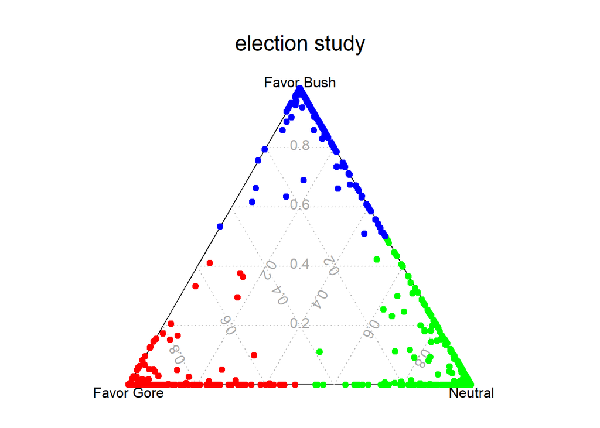

```r
#graph
colnames(lcrm.1$posterior) <- c('Favor Gore','Neutral','Favor Bush')
ternaryplot(lcrm.1$posterior,cex=0.5,main='election study',
            col=c('red','green','blue')[lcrm.1$predclass])
```

위의 terenaryplot은 election자료의 층 사후확률이다. 각 개체의 사후확률을 표기한 그래프이며 각 개채마다 어느 class에 속하는지와 각 class에 대한 확률을 읽을 수 있다. (삼각형좌표)

```r
#logistic
data(election)
f.2 <- cbind(MORALG,CARESG,KNOWG,LEADG,DISHONG,INTELG,
             MORALB,CARESB,KNOWB,LEADB,DISHONB,INTELB) ~ 1

set.seed(123)
lca.2 <- poLCA(f.2,election,nclass=3,nrep=5,na.rm=F)
```

```
## Model 1: llik = -21311.55 ... best llik = -21311.55
## Model 2: llik = -21311.54 ... best llik = -21311.54
## Model 3: llik = -21311.55 ... best llik = -21311.54
## Model 4: llik = -21311.55 ... best llik = -21311.54
## Model 5: llik = -21311.55 ... best llik = -21311.54
## Conditional item response (column) probabilities,
##  by outcome variable, for each class (row)
##
## $MORALG
##           1 Extremely well 2 Quite well 3 Not too well 4 Not well at all
## class 1:            0.5915       0.3633         0.0199            0.0253
## class 2:            0.1446       0.3649         0.2677            0.2228
## class 3:            0.1057       0.6650         0.2093            0.0200
##
## $CARESG
##           1 Extremely well 2 Quite well 3 Not too well 4 Not well at all
## class 1:            0.4834       0.4107         0.0506            0.0553
## class 2:            0.0522       0.2348         0.3946            0.3183
## class 3:            0.0282       0.5578         0.3437            0.0703
##
## $KNOWG
##           1 Extremely well 2 Quite well 3 Not too well 4 Not well at all
## class 1:            0.6823       0.2892         0.0000            0.0285
## class 2:            0.1795       0.5002         0.2368            0.0835
## class 3:            0.0553       0.8143         0.1257            0.0047
##
## $LEADG
##           1 Extremely well 2 Quite well 3 Not too well 4 Not well at all
## class 1:            0.4651       0.4520         0.0487            0.0342
## class 2:            0.0447       0.2239         0.4392            0.2922
## class 3:            0.0195       0.5554         0.3905            0.0346
##
## $DISHONG
##           1 Extremely well 2 Quite well 3 Not too well 4 Not well at all
## class 1:            0.0417       0.0523         0.2739            0.6322
## class 2:            0.2025       0.3326         0.2844            0.1805
## class 3:            0.0260       0.1863         0.5265            0.2613
##
## $INTELG
##           1 Extremely well 2 Quite well 3 Not too well 4 Not well at all
```

[output cut: 45 more lines]

```
##
## =========================================================
## Fit for 3 latent classes:
## =========================================================
## number of observations: 1785
## number of fully observed cases: 1311
## number of estimated parameters: 110
## residual degrees of freedom: 1675
## maximum log-likelihood: -21311.54
##
## AIC(3): 42843.07
## BIC(3): 43446.66
## G^2(3): 15054.59 (Likelihood ratio/deviance statistic)
## X^2(3): 24746990634 (Chi-square goodness of fit)
##
```

이번엔 잠재층에 대해 로지스틱 회귀를 적용해보려고 한다. 위의 코드는 공변량은 없고 층의 수가 3인 잠재층 모형을 고려한 결과이다. 여기까지는 일반적인 잠재층 분석과 다를바가 없다.

```r
subset <- (lca.2$predclass != 3)
election$Z.1 <- lca.2$predclass -1
logistic <- glm(Z.1~ AGE + GENDER + EDUC + PARTY , data=election[subset,],family=binomial())
summary(logistic)
```

```
##
## Call:
## glm(formula = Z.1 ~ AGE + GENDER + EDUC + PARTY, family = binomial(),
##     data = election[subset, ])
##
## Deviance Residuals:
##     Min       1Q   Median       3Q      Max
## -2.6375  -0.4926   0.2037   0.4657   2.5076
##
## Coefficients:
##              Estimate Std. Error z value Pr(>|z|)
## (Intercept) -2.270690   0.517427  -4.388 1.14e-05 ***
## AGE         -0.008117   0.005593  -1.451   0.1467
## GENDER      -0.224449   0.192428  -1.166   0.2435
## EDUC        -0.153198   0.060783  -2.520   0.0117 *
## PARTY        1.027711   0.059048  17.405  < 2e-16 ***
## ---
## Signif. codes:  0 '***' 0.001 '**' 0.01 '*' 0.05 '.' 0.1 ' ' 1
##
## (Dispersion parameter for binomial family taken to be 1)
##
##     Null deviance: 1352.61  on 975  degrees of freedom
## Residual deviance:  724.34  on 971  degrees of freedom
##   (17 observations deleted due to missingness)
## AIC: 734.34
##
## Number of Fisher Scoring iterations: 5
```

그리고 위에서 얻어진 잠재층을 가지고 AGE, GENDER, EDUC, PARTY 변수에 대한 로지스틱 회귀를 적용해서 분석해보면 위와 같은 결과를 얻는다.PARTY변수와 EDUC 변수가 유의하며 PARTY는 + , EDUC는 - 상관관계를 지님을 확인할 수 있다.

### 3장

```r
# Propensity Score Matching
data(lalonde)
str(lalonde)
```

```
## 'data.frame':    614 obs. of  10 variables:
##  $ treat   : int  1 1 1 1 1 1 1 1 1 1 ...
##  $ age     : int  37 22 30 27 33 22 23 32 22 33 ...
##  $ educ    : int  11 9 12 11 8 9 12 11 16 12 ...
##  $ black   : int  1 0 1 1 1 1 1 1 1 0 ...
##  $ hispan  : int  0 1 0 0 0 0 0 0 0 0 ...
##  $ married : int  1 0 0 0 0 0 0 0 0 1 ...
##  $ nodegree: int  1 1 0 1 1 1 0 1 0 0 ...
##  $ re74    : num  0 0 0 0 0 0 0 0 0 0 ...
##  $ re75    : num  0 0 0 0 0 0 0 0 0 0 ...
##  $ re78    : num  9930 3596 24909 7506 290 ...
```

```r
summary(lalonde$re78[lalonde$treat==1])
```

```
##    Min. 1st Qu.  Median    Mean 3rd Qu.    Max.
##     0.0   485.2  4232.3  6349.1  9643.0 60307.9
```

```r
summary(lalonde$re78[lalonde$treat==0])
```

```
##    Min. 1st Qu.  Median    Mean 3rd Qu.    Max.
##     0.0   220.2  4975.5  6984.2 11688.8 25564.7
```

배후요인을 고려하지 않고 데이터의 구조를 보면 위와같은 형태를 가지고 있음을 알수있다.

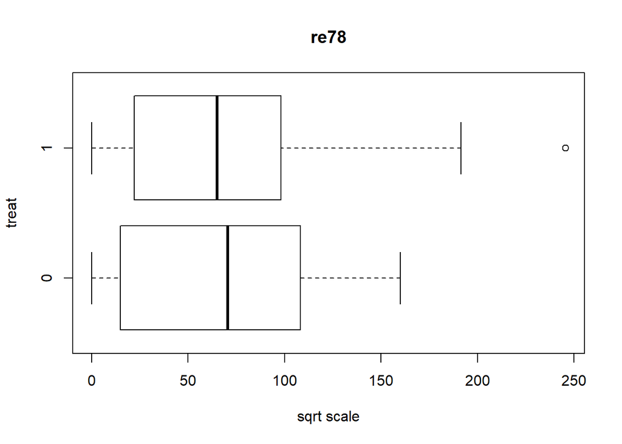

```r
boxplot(sqrt(re78) ~ treat, data=lalonde, horizontal=T, main="re78", ylab="treat", xlab="sqrt scale")
```

이를 box plot으로 나타내면 위와 같다.

```r
# nearest neighbor matching
matchit(treat ~ re74 + re75 + educ + black + hispan + age, method = "nearest", data = lalonde)
```

```
##
## Call:
## matchit(formula = treat ~ re74 + re75 + educ + black + hispan +
##     age, data = lalonde, method = "nearest")
##
## Sample sizes:
##           Control Treated
## All           429     185
## Matched       185     185
## Unmatched     244       0
## Discarded       0       0
```

이번엔 배후요인을 고려한 분석을 시행해보자. 방법으로는 최근접 이웃맞추기를 택하였다. 이때 매칭된 개수는 185개임을 확인할 수 있다.

```r
matchit(treat ~ re74 + re75 + educ + black + hispan + age, data = lalonde, method = "nearest", discard="both", ratio=2)
```

```
##
## Call:
## matchit(formula = treat ~ re74 + re75 + educ + black + hispan +
##     age, data = lalonde, method = "nearest", discard = "both",
##     ratio = 2)
##
## Sample sizes:
##           Control Treated
## All           429     185
## Matched       324     185
## Unmatched       0       0
## Discarded     105       0
```

이번엔 처리1개에 대조2개를 비율로 맞추고 최근접 이웃맞추기 방법을 그대로 진행하되, 양쪽에 겹치지 않는 데이터는 버리는 행동을 취했다. 그 결과 324:185개의 쌍이 맞춰 졌으며 대조군 그룹중 105개의 데이터는 버려짐을 확인할 수 있다.

```r
m.out <- matchit(treat ~ re74 + re75 + educ + black + hispan + age, data = lalonde, method = "nearest", discard="both", ratio=2)
m.lalonde <- match.data(m.out)
y1 <- m.lalonde$re78[m.lalonde$treat==1]
y0 <- m.lalonde$re78[m.lalonde$treat==0]
w1 <- m.lalonde$weights[m.lalonde$treat==1]
w0 <- m.lalonde$weights[m.lalonde$treat==0]
weighted.mean(y1, w1); weighted.mean(y0, w0)
```

```
## [1] 6349.144
```

```
## [1] 5719.173
```

위에서 진행한 최근접이웃방법에 양쪽버리기를 택하고, 처리:대조 비율을 1:2로 한 성향점수 맞추기 방법을 통해 얻은 결과이다. 배후요인을 고려하게 되면 대조요인 평균이 6984에서 5719로 조절됨을 확인할 수있다.

```r
rq(y1 ~ 1, weights=w1, tau=c(0.25,0.5,0.75))
```

```
## Call:
## rq(formula = y1 ~ 1, tau = c(0.25, 0.5, 0.75), weights = w1)
##
## Coefficients:
##             tau= 0.25 tau= 0.50 tau= 0.75
## (Intercept)  485.2298  4232.309  9642.999
##
## Degrees of freedom: 185 total; 184 residual
```

```r
rq(y0 ~ 1, weights=w0, tau=c(0.25,0.5,0.75))
```

```
## Call:
## rq(formula = y0 ~ 1, tau = c(0.25, 0.5, 0.75), weights = w0)
##
## Coefficients:
##             tau= 0.25 tau= 0.50 tau= 0.75
## (Intercept)  31.03226   3392.86  9088.018
##
## Degrees of freedom: 324 total; 323 residual
```

그리고 이렇게 가중치로 조절된 값에 대해 상위 25%, 50%, 75% 를 살펴보면 위와 같다. y1이 처리그룹, y0는 대조그룹에 대한 정보이다.

```r
# Propensity Score Matching, subclass matching
data(lalonde)
m.out <- matchit(treat ~ re74 + re75 + educ + black + hispan + age, data = lalonde, method = "subclass")
m.lalonde <- match.data(m.out)
y1 <- m.lalonde$re78[m.lalonde$treat==1]
y0 <- m.lalonde$re78[m.lalonde$treat==0]
w1 <- m.lalonde$weights[m.lalonde$treat==1]
w0 <- m.lalonde$weights[m.lalonde$treat==0]
weighted.mean(y1, w1); weighted.mean(y0, w0)
```

```
## [1] 6349.144
```

```
## [1] 5364.761
```

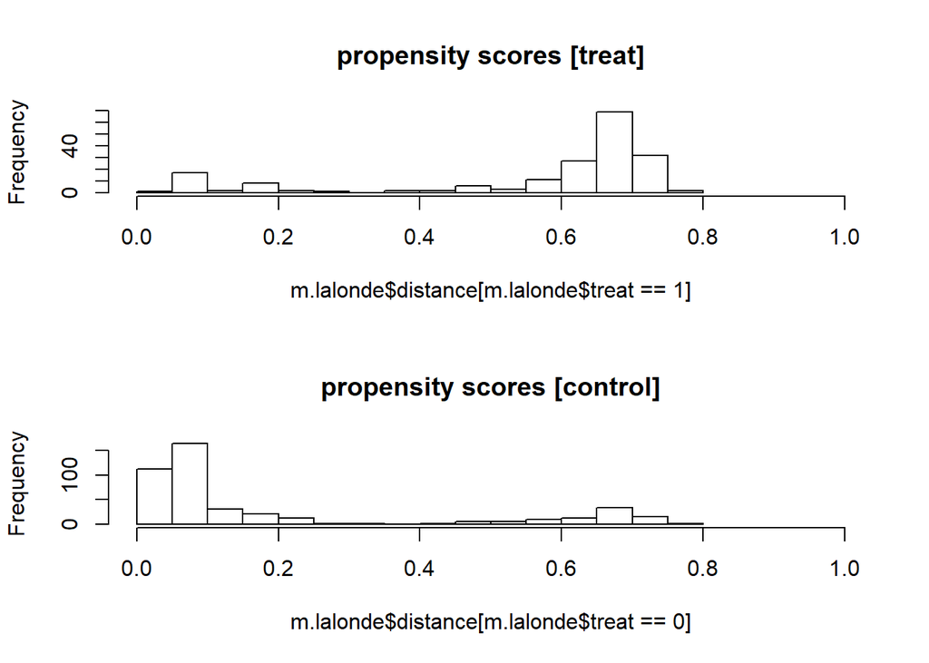

```r
par(mfrow=c(2,1))
wtd.hist(m.lalonde$distance[m.lalonde$treat==1],nclass=20,main="propensity scores [treat]",xlim=c(0,1))
wtd.hist(m.lalonde$distance[m.lalonde$treat==0],nclass=20,main="propensity scores [control]",xlim=c(0,1))
```

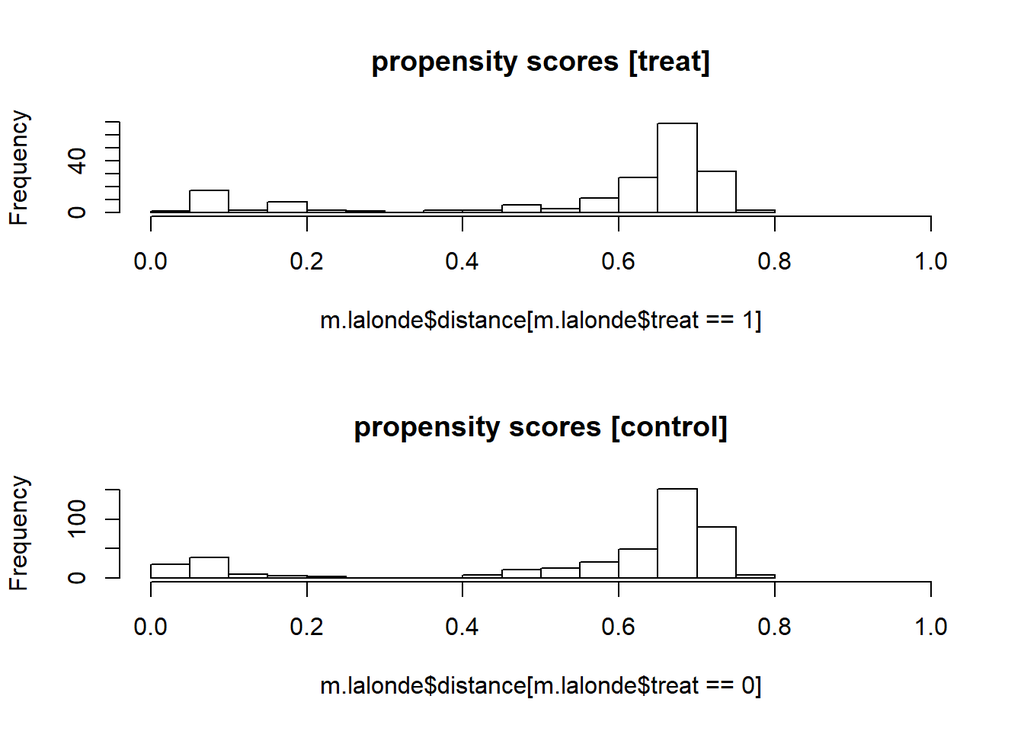

```r
x11(); par(mfrow=c(2,1))
wtd.hist(m.lalonde$distance[m.lalonde$treat==1],weight=w1,nclass=20,main="propensity scores [treat]",xlim=c(0,1))
wtd.hist(m.lalonde$distance[m.lalonde$treat==0],weight=w0,nclass=20,main="propensity scores [control]",xlim=c(0,1))
```

그렇게 배후요인이 조정된 성향점수의 분포에 대해 확인하면 위와 같다.

### 4장

```r
# example 1. Poisson observations
x <- c(3,10,5,4)
n <- length(x)
n.log.lik <- function(mu) n*mu - sum(x)*log(mu)
optim(n.log.lik, method="L-BFGS-B", par =1, lower=0, upper=100)
```

```
## $par
## [1] 5.5
##
## $value
## [1] -15.50446
##
## $counts
## function gradient
##        9        9
##
## $convergence
## [1] 0
##
## $message
## [1] "CONVERGENCE: REL_REDUCTION_OF_F <= FACTR*EPSMCH"
```

포아송의 최대가능도 추정치와 log-liklihood구하면 위와 같다. 모수 추정치 $\hat{\theta} = 5.5$ 이고, $l(\hat{\theta}) = 15.5$ 이다. 위에서 value 값은 음의 가능도 값이다.

```r
# example 2. Weibull observations
x <- c(1,1,2,2,3,4,4,5,5,8,8,8,8,11,11,12,12,15,17,22,23)
n <- length(x)
n.log.lik <- function(theta) {
  theta.1 <- theta[1] ; theta.2 <- theta[2]
  temp.1 <- -n*log(theta.1/theta.2) - (theta.1-1)*sum(log(x/theta.2))
  temp.2 <- sum((x/theta.2)^theta.1)
  return( temp.1 + temp.2)
}
optim(fn=n.log.lik, par=c(1,10), method="L-BFGS-B", lower=c(0,0))
```

```
## $par
## [1] 1.370500 9.482141
##
## $value
## [1] 64.92011
##
## $counts
## function gradient
##       11       11
##
## $convergence
## [1] 0
##
## $message
## [1] "CONVERGENCE: REL_REDUCTION_OF_F <= FACTR*EPSMCH"
```

마찬가지로, 이번엔 와이블 분포에 대한 최대가능도 추정치(최적화)를 구해보았다. 이때 , $(\hat{\theta_{1}} , \hat{\theta_{2}}) = (1.37,9.48)$ 이고, $l(\hat{\theta_{1}} , \hat{\theta_{2}}) = -64.92$ 이다. 이를 Nelder-Mead 방법으로 구하면 아래와 같다.

```r
optim(fn=n.log.lik, par=c(1,10), method="Nelder-Mead")
```

```
## $par
## [1] 1.370393 9.482312
##
## $value
## [1] 64.92011
##
## $counts
## function gradient
##       51       NA
##
## $convergence
## [1] 0
##
## $message
## NULL
```

추정된 값들은 같음을 알 수 있다. 다만, 이 알고리즘에서는 gradient는 계산되지 않으므로 NA가 출력된다.

```r
# example 1 (continued)
x <- c(3,10,5,4)
n <- length(x)
n.log.lik <- function(mu) n*mu - sum(x)*log(mu)
fitted <- mle(n.log.lik, start=list(mu=1), nobs=n)
logLik(fitted)
```

```
## 'log Lik.' 15.50446 (df=1)
```

```r
summary(fitted)
```

```
## Maximum likelihood estimation
##
## Call:
## mle(minuslogl = n.log.lik, start = list(mu = 1), nobs = n)
##
## Coefficients:
##    Estimate Std. Error
## mu      5.5   1.172604
##
## -2 log L: -31.00892
```

```r
confint(fitted)
```

```
## Profiling...
```

```
##    2.5 %   97.5 %
## 3.510833 8.129185
```

이를 mle함수를 통해 구할수도 있다. logLik함수를 사용하면 로그가능도 최댓값을 출력하고, 모수의 95% 신뢰구간, Deviance값도 출력해준다.

```r
# example 2 (continued)
n.log.lik <- function(theta.1,theta.2) {
  temp.1 <- -n*log(theta.1/theta.2) - (theta.1-1)*sum(log(x/theta.2))
  temp.2 <- sum((x/theta.2)^theta.1)
  return( temp.1 + temp.2)
}
fitted <- mle(n.log.lik,start=list(theta.1=1,theta.2=10),nobs=n)
logLik(fitted)
```

```
## 'log Lik.' -9.294468 (df=2)
```

```r
summary(fitted)
```

```
## Maximum likelihood estimation
##
## Call:
## mle(minuslogl = n.log.lik, start = list(theta.1 = 1, theta.2 = 10),
##     nobs = n)
##
## Coefficients:
##         Estimate Std. Error
## theta.1 2.208432  0.8272226
## theta.2 6.253783  1.5058546
##
## -2 log L: 18.58894
```

```r
confint(fitted)
```

```
## Profiling...
```

```
##             2.5 %    97.5 %
## theta.1 0.8862356  4.182984
## theta.2 3.3689636 11.342923
```

```r
vcov(fitted)
```

```
##           theta.1   theta.2
## theta.1 0.6842973 0.4241059
## theta.2 0.4241059 2.2675981
```

덧붙여 위의 결과는 와이블 분포를 mle함수를 통해 적합시키고 요약을 한 결과이다.

```r
# example 3. exponential growth
growth <- read.table("C:\\Users\\82104\\Desktop\\Applied Data Analysis Using R\\Applied Data Analysis Using R\\04_optimization\\growth.txt",header=T)
str(growth)
```

```
## 'data.frame':    20 obs. of  2 variables:
##  $ x: int  20 30 40 50 60 70 80 90 100 110 ...
##  $ y: num  0.57 0.72 0.81 0.87 0.91 0.94 0.95 0.97 0.98 0.99 ...
```

```r
attach(growth)
rss <- function(beta){
  beta.1 <- beta[1]; beta.2 <- beta[2]
  fit <- beta.1*(1-exp(-beta.2 * x))
  err <- y - fit
  return(sum(err*err))
}
optim(fn=rss, par=c(1,0.5))
```

```
## $par
## [1] 0.9502033 1.0190578
##
## $value
## [1] 0.2361934
##
## $counts
## function gradient
##       77       NA
##
## $convergence
## [1] 0
##
## $message
## NULL
```

```r
optim(fn=rss, par=c(1,0.5), method="L-BFGS-B", lower=c(0,0))
```

```
## $par
## [1] 0.9501966 1.0193410
##
## $value
## [1] 0.2361934
##
## $counts
## function gradient
##       15       15
##
## $convergence
## [1] 0
##
## $message
## [1] "CONVERGENCE: REL_REDUCTION_OF_F <= FACTR*EPSMCH"
```

이를 L-BFGS-B방법을 통해 돌려본 결과이다. parameter의 경우 위와 살짝 다르지만, 크게다르지는 않다.

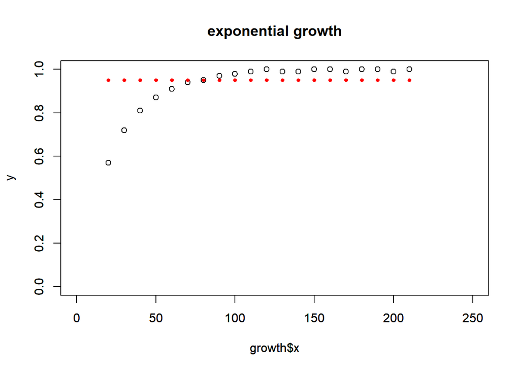

```r
nlrm <- optim(par=c(1,0),fn = rss)
beta <- nlrm$par
beta.1 <- beta[1]; beta.2 <- beta[2]
fit <- beta.1*(1-exp(-beta.2*growth$x))
plot(growth$x,growth$y,pch=21,xlim=c(0,250),ylim=c(0,1),main="exponential growth",ylab="y")
par(new=T); plot(growth$x,fit,pch=19,cex=0.6,col="red",xlim=c(0,250),ylim=c(0,1),ylab="")
```

그리고 위의 결과를 가지고 실제 데이터와 모형의 fitting값을 찍어본 결과이다. 빨간색이 Y의 fitting된 결과값이다.

```r
# example 4. constant elasticity of substitution
ces <- read.table("C:\\Users\\82104\\Desktop\\Applied Data Analysis Using R\\Applied Data Analysis Using R\\04_optimization\\ces.txt",header=T)
str(ces)
```

```
## 'data.frame':    30 obs. of  3 variables:
##  $ x1: num  0.228 0.821 0.495 0.678 0.727 0.458 0.002 0.231 0.631 0.811 ...
##  $ x2: num  0.802 0.771 0.758 0.452 0.845 0.084 0.295 0.546 0.017 0.223 ...
##  $ y : num  -1.359 0.193 -0.165 -0.473 -0.563 ...
```

```r
attach(ces)
rss <- function(beta){
  beta.0 <- beta[1]; beta.1 <- beta[2]; beta.2 <- beta[3]; beta.3 <- beta[4]
  fit <- beta.0 + beta.1*log(beta.2*x1^beta.3+(1-beta.2)*x2^beta.3)
  err <- y - fit
  return(sum(err*err))
}
optim(fn=rss, par=c(1,-1,0.5,-1), method="L-BFGS-B", lower=c(0,-10,0,-10), upper=c(10,0,1,0))
```

```
## $par
## [1]  0.1244750 -0.3363035  0.3366845 -3.0109298
##
## $value
## [1] 1.761039
##
## $counts
## function gradient
##       80       80
##
## $convergence
## [1] 0
##
## $message
## [1] "CONVERGENCE: REL_REDUCTION_OF_F <= FACTR*EPSMCH"
```

```r
# TSP for protein data
protein <- read.table("C:\\Users\\82104\\Desktop\\Applied Data Analysis Using R\\Applied Data Analysis Using R\\04_optimization\\protein.txt",header=T)
str(protein)
```

```
## 'data.frame':    25 obs. of  10 variables:
##  $ Country: Factor w/ 25 levels "Albania","Austria",..: 1 2 3 4 5 6 7 8 9 10 ...
##  $ Beef   : num  10.1 8.9 13.5 7.8 9.7 10.6 8.4 9.5 18 10.2 ...
##  $ Chicken: num  1.4 14 9.3 6 11.4 10.8 11.6 4.9 9.9 3 ...
##  $ Egg    : num  0.5 4.3 4.1 1.6 2.8 3.7 3.7 2.7 3.3 2.8 ...
##  $ Milk   : num  8.9 19.9 17.5 8.3 12.5 25 11.1 33.7 19.5 17.6 ...
##  $ Fish   : num  0.2 2.1 4.5 1.2 2 9.9 5.4 5.8 5.7 5.9 ...
##  $ Cereal : num  42.3 28 26.6 56.7 34.3 21.9 24.6 26.3 28.1 41.7 ...
##  $ Potato : num  0.6 3.6 5.7 1.1 5 4.8 6.5 5.1 4.8 2.2 ...
##  $ Bean   : num  5.5 1.3 2.1 3.7 1.1 0.7 0.8 1 2.4 7.8 ...
##  $ Fruit  : num  1.7 4.3 4 4.2 4 2.4 3.6 1.4 6.5 6.5 ...
```

```r
country <- protein$Country
X <- scale(protein[,2:10])
D <- dist(X)
D.tsp <- TSP(D,labels=country)
solve_TSP(D.tsp,method="repetitive_nn")
```

```
## object of class 'TOUR'
## result of method 'repetitive_nn' for 25 cities
## tour length: 60.76182
```

경로의 거리 총합은 repetitive_nn 방법으로 위의 결과,

```r
solve_TSP(D.tsp,method="2-opt")
```

```
## object of class 'TOUR'
## result of method '2-opt' for 25 cities
## tour length: 58.65053
```

2-opt 방법으로는 위의 거리결과를 출력한다.

```r
tsp.country <- solve_TSP(D.tsp,method="2-opt")
labels(tsp.country)
```

```
##  [1] "Hungary"    "Rumania"    "Yugoslavia" "Albania"    "Bulgaria"
##  [6] "Italy"      "Greece"     "Spain"      "Portugal"   "Norway"
## [11] "Finland"    "Sweden"     "Denmark"    "Ireland"    "Bel-Luxem"
## [16] "U-Kingdom"  "France"     "Swiss"      "Austria"    "Netherland"
## [21] "W-Germany"  "E-Germany"  "Czecho"     "Poland"     "USSR"
```

그리고 2-opt방법을 이용해서 TSP 에 대한 경로를 확인하면 위의 결과를 얻을 수 있다. 이때, TSP의 해는 원형고리이므로 처음과 끝은 이웃한다.

```r
D.plus <- insert_dummy(D.tsp, label = "cut")
tsp.country.plus <- solve_TSP(D.plus, method="2-opt")
tsp.country.plus
```

```
## object of class 'TOUR'
## result of method '2-opt' for 26 cities
## tour length: 53.99354
```

그리고 이경우는 안돌아 와도 되는 경우이며, 위의 거리결과를 출력한다. 새로운 변수 cut을 추가해 줌으로써 분석을 진행한다.

```r
tsp.country.cut <- cut_tour(tsp.country.plus, "cut")
labels(tsp.country.cut)
```

```
##  [1] "Portugal"   "Spain"      "Greece"     "Italy"      "Hungary"
##  [6] "Austria"    "Netherland" "W-Germany"  "Bel-Luxem"  "Ireland"
## [11] "U-Kingdom"  "France"     "Swiss"      "Finland"    "Norway"
## [16] "Sweden"     "Denmark"    "E-Germany"  "Czecho"     "Poland"
## [21] "USSR"       "Rumania"    "Yugoslavia" "Bulgaria"   "Albania"
```

그리고 위의 결과는 안돌아와도 되는 경우의 루트이다.

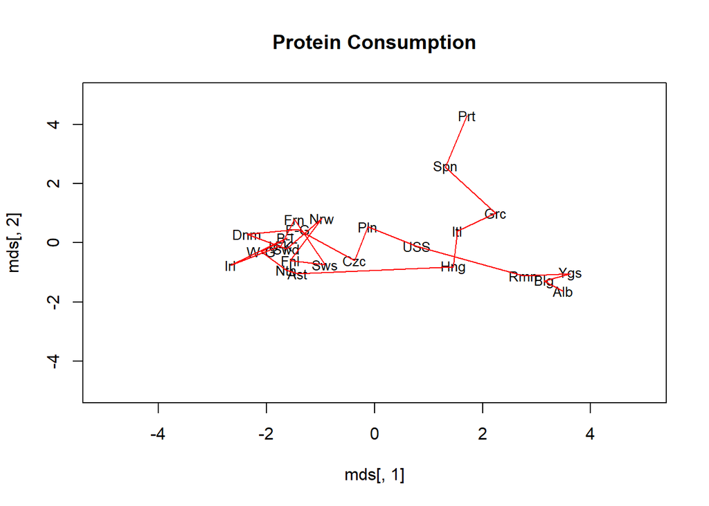

```r
mds <- cmdscale(D)
plot(mds[,1],mds[,2],type="n", xlim=c(-5,5),ylim=c(-5,5),main="Protein Consumption")
text(mds[,1],mds[,2],abbreviate(country,minlength=3),cex=0.8)
seq.mds <- as.integer(tsp.country.cut)
for (i in 2:length(country)){
  segments(mds[seq.mds[i-1],1],mds[seq.mds[i-1],2],mds[seq.mds[i],1],mds[seq.mds[i],2],col="red")
}
```

그리고 안돌아와도 되는 경우의 루트를 그림으로 그리면 위와 같다.

### 5장

```r
data(nhanes)
str(nhanes)
```

```
## 'data.frame':    25 obs. of  4 variables:
##  $ age: num  1 2 1 3 1 3 1 1 2 2 ...
##  $ bmi: num  NA 22.7 NA NA 20.4 NA 22.5 30.1 22 NA ...
##  $ hyp: num  NA 1 1 NA 1 NA 1 1 1 NA ...
##  $ chl: num  NA 187 187 NA 113 184 118 187 238 NA ...
```

nhanes의 데이터 구조는 위와같다.

```r
pattern <- md.pattern(nhanes)
```

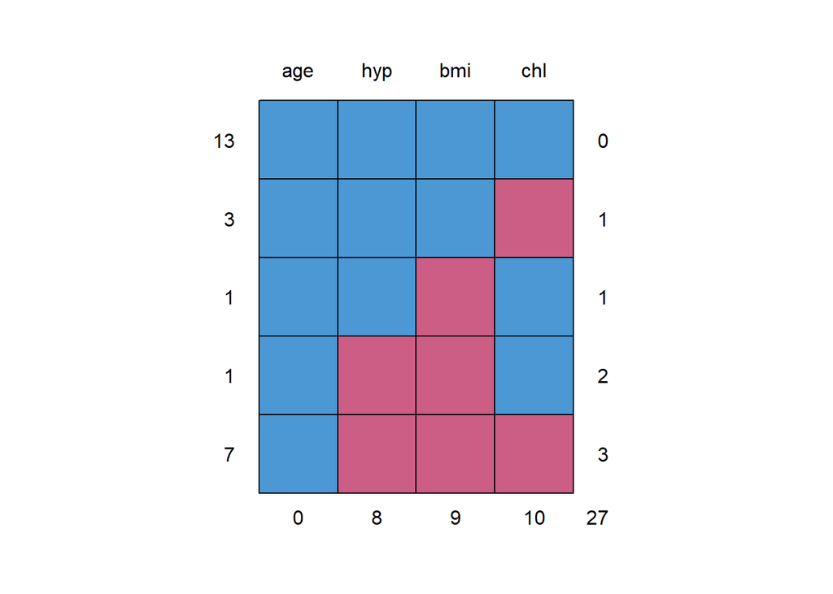

그리고 각 변수에 대한 결측치 조합과 개수를 살펴보면 위처럼 그래프로 나타낼 수 있다.

```r
colnames(pattern)[ncol(pattern)] <- "# miss"
rownames(pattern)[nrow(pattern)] <- "# miss"
pattern
```

```
##        age hyp bmi chl # miss
## 13       1   1   1   1      0
## 3        1   1   1   0      1
## 1        1   1   0   1      1
## 1        1   0   0   1      2
## 7        1   0   0   0      3
## # miss   0   8   9  10     27
```

```r
md.pairs(nhanes)
```

```
## $rr
##     age bmi hyp chl
## age  25  16  17  15
## bmi  16  16  16  13
## hyp  17  16  17  14
## chl  15  13  14  15
##
## $rm
##     age bmi hyp chl
## age   0   9   8  10
## bmi   0   0   0   3
## hyp   0   1   0   3
## chl   0   2   1   0
##
## $mr
##     age bmi hyp chl
## age   0   0   0   0
## bmi   9   0   1   2
## hyp   8   0   0   1
## chl  10   3   3   0
##
## $mm
##     age bmi hyp chl
## age   0   0   0   0
## bmi   0   9   8   7
## hyp   0   8   8   7
## chl   0   7   7  10
```

혹은 수치로 보면 위와 같다.

```r
mice(nhanes, seed=23109, m=5)
```

```
## Class: mids
## Number of multiple imputations:  5
## Imputation methods:
##   age   bmi   hyp   chl
##    "" "pmm" "pmm" "pmm"
## PredictorMatrix:
##     age bmi hyp chl
## age   0   1   1   1
## bmi   1   0   1   1
## hyp   1   1   0   1
## chl   1   1   1   0
```

col 변수를 이용해서 Missing 데이터의 값을 이끌어 낸다. 이때, 각 변수의 Missing 에 대해서는 pmm방법을 쓴다. 이 방법은 목표변수가 수치형인 경우에 사용한다.

```r
# use data nhanes2
data(nhanes2)
str(nhanes2)
```

```
## 'data.frame':    25 obs. of  4 variables:
##  $ age: Factor w/ 3 levels "20-39","40-59",..: 1 2 1 3 1 3 1 1 2 2 ...
##  $ bmi: num  NA 22.7 NA NA 20.4 NA 22.5 30.1 22 NA ...
##  $ hyp: Factor w/ 2 levels "no","yes": NA 1 1 NA 1 NA 1 1 1 NA ...
##  $ chl: num  NA 187 187 NA 113 184 118 187 238 NA ...
```

이번엔 nhanes2데이터에 대해 살펴보자. 다른점이란 age와 hyp가 factor로 들어온것 뿐이다.

```r
mice(nhanes2, seed=23109, m=5)
```

```
## Class: mids
## Number of multiple imputations:  5
## Imputation methods:
##      age      bmi      hyp      chl
##       ""    "pmm" "logreg"    "pmm"
## PredictorMatrix:
##     age bmi hyp chl
## age   0   1   1   1
## bmi   1   0   1   1
## hyp   1   1   0   1
## chl   1   1   1   0
```

그리고 결과를 돌리면 위와 같다. 이대 hyp변수는 logreg의 방법을 취하고, 목표변수가 이항형인 경우에 해당한다.

```r
imp.mice <- mice(nhanes2, seed=23109, m=10)
print(imp.mice)
```

```
## Class: mids
## Number of multiple imputations:  10
## Imputation methods:
##      age      bmi      hyp      chl
##       ""    "pmm" "logreg"    "pmm"
## PredictorMatrix:
##     age bmi hyp chl
## age   0   1   1   1
## bmi   1   0   1   1
## hyp   1   1   0   1
## chl   1   1   1   0
```

위의 결과는 m=10으로, Missing을 채워넣는 행위를 10번 다르게 진행한다.

```r
imp.mice$imp$bmi
```

```
##       1    2    3    4    5    6    7    8    9   10
## 1  25.5 30.1 29.6 27.2 29.6 33.2 29.6 26.3 33.2 30.1
## 3  35.3 28.7 29.6 30.1 30.1 30.1 30.1 26.3 35.3 28.7
## 4  22.0 27.5 21.7 21.7 27.4 27.4 28.7 28.7 22.5 27.4
## 6  20.4 25.5 20.4 22.5 24.9 25.5 25.5 22.7 20.4 27.4
## 10 25.5 26.3 27.2 25.5 24.9 28.7 27.4 22.5 28.7 26.3
## 11 33.2 22.5 22.0 22.0 27.2 35.3 29.6 22.0 35.3 22.0
## 12 27.4 27.4 26.3 27.2 21.7 29.6 26.3 29.6 30.1 33.2
## 16 33.2 27.2 27.2 30.1 27.2 33.2 30.1 27.2 28.7 27.2
## 21 30.1 27.2 35.3 33.2 29.6 33.2 28.7 22.5 30.1 25.5
```

```r
imp.mice$imp$hyp
```

```
##      1   2  3   4   5   6   7   8   9  10
## 1   no  no no  no  no  no  no  no  no yes
## 4   no yes no  no yes yes  no yes yes yes
## 6   no yes no  no yes yes  no yes  no yes
## 10  no yes no yes yes  no yes yes  no yes
## 11  no  no no  no  no  no  no  no  no  no
## 12  no yes no  no  no yes yes yes yes yes
## 16 yes  no no  no  no  no  no  no yes yes
## 21  no  no no  no  no yes  no  no  no yes
```

```r
imp.mice$imp$chl
```

```
##      1   2   3   4   5   6   7   8   9  10
## 1  238 199 187 187 187 238 187 187 184 131
## 4  186 204 199 184 284 184 199 218 186 229
## 10 199 131 199 131 187 284 186 187 206 238
## 11 229 131 187 187 187 204 187 131 229 131
## 12 186 131 229 206 187 186 229 218 204 184
## 15 131 238 238 184 238 187 131 204 131 187
## 16 187 187 238 186 187 187 238 238 229 187
## 20 204 229 218 186 284 206 284 206 206 238
## 21 131 187 184 184 238 187 131 238 131 187
## 24 284 184 204 204 284 229 284 284 206 284
```

위의 결과는 각 변수별로 10번의 Missing을 채워넣는 행위를 하고난 뒤 어떤 값들로 Missing이 대체되었나 확인하는 결과이다. bmi의 경우 9개의 데이터가, hyp의경우 8개, chl의 경우 10개의 데이터들이 비어있었다.

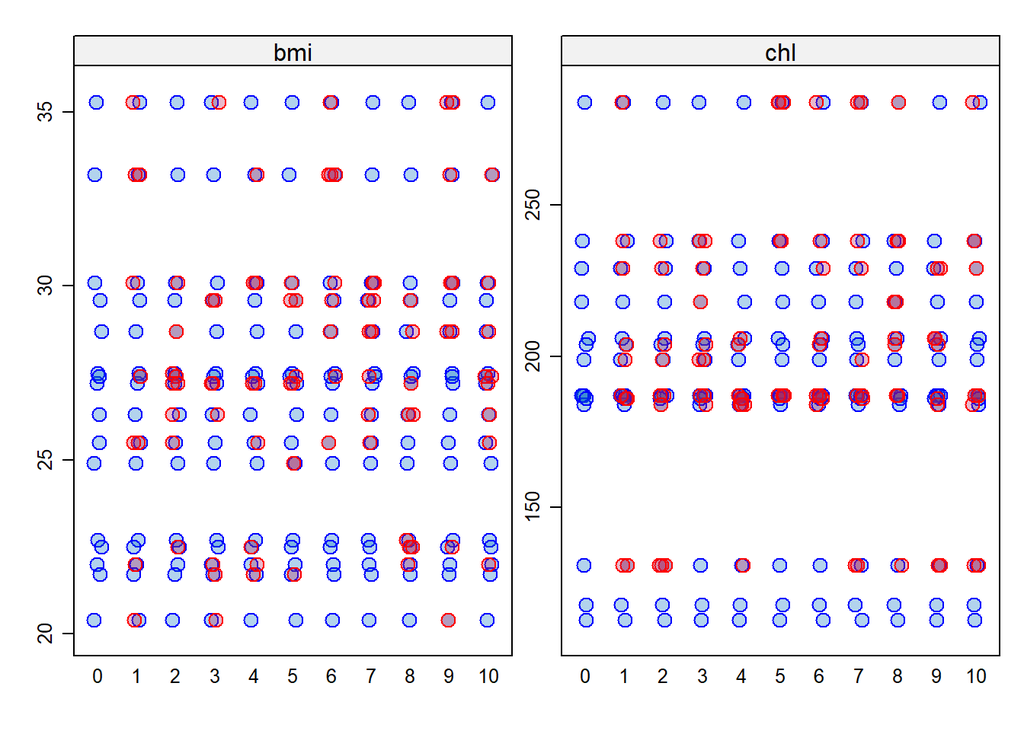

```r
stripplot(imp.mice, pch=21, cex=1.2, col=c("blue","red"))
```

0번째는 원자료를 지칭하고, 나머지는 각 횟수에 대해 빨간색 원(imputation)이 일어남을 확인할 수 있다.

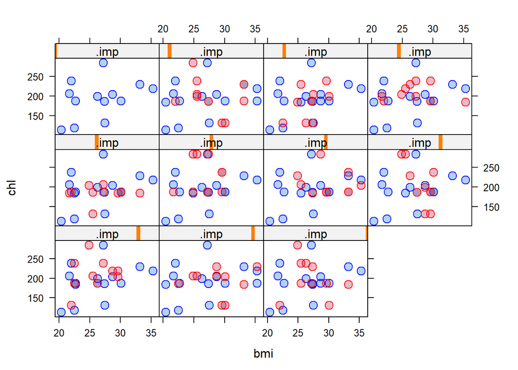

```r
xyplot(imp.mice, chl~bmi|.imp, pch=21, col=c("blue","red"), cex=1.4)
```

그리고 chl, bmi변수를 통해 x,y plot을 본 결과는 위와 같다.

```r
# application
fit <- with(imp.mice, lm(chl ~ age + bmi))
print(pool(fit))
```

```
## Class: mipo    m = 10
##             estimate        ubar           b           t dfcom       df
## (Intercept) 13.28407 3115.588355 706.8244215 3893.095219    21 14.42093
## age40-59    39.79510  284.381721 135.5244657  433.458633    21 10.83158
## age60-99    70.88528  340.704848 225.2116671  588.437682    21  9.13960
## bmi          5.70809    3.687217   0.7968897    4.563796    21 14.62053
##                   riv    lambda       fmi
## (Intercept) 0.2495538 0.1997143 0.2915906
## age40-59    0.5242141 0.3439242 0.4387905
## age60-99    0.7271186 0.4210010 0.5163911
## bmi         0.2377345 0.1920723 0.2837753
```

```r
round(summary(pool(fit)),2)
```

```
##             estimate std.error statistic    df p.value
## (Intercept)    13.28     62.39      0.21 14.42    0.83
## age40-59       39.80     20.82      1.91 10.83    0.08
## age60-99       70.89     24.26      2.92  9.14    0.02
## bmi             5.71      2.14      2.67 14.62    0.02
```

```r
fit.hyp <- with(imp.mice, glm(hyp ~ bmi + chl, family=binomial()))
print(pool(fit.hyp))
```

```
## Class: mipo    m = 10
##                estimate         ubar            b            t dfcom
## (Intercept) -4.03199466 1.770642e+01 4.0979547429 2.221417e+01    22
## bmi         -0.01645023 1.634843e-02 0.0032603236 1.993479e-02    22
## chl          0.01707800 1.927637e-04 0.0000926589 2.946885e-04    22
##                   df       riv    lambda       fmi
## (Intercept) 15.02390 0.2545829 0.2029223 0.2913691
## bmi         15.66374 0.2193701 0.1799044 0.2677856
## chl         11.25830 0.5287551 0.3458730 0.4376269
```

```r
round(summary(pool(fit.hyp)),2)
```

```
##             estimate std.error statistic    df p.value
## (Intercept)    -4.03      4.71     -0.86 15.02    0.41
## bmi            -0.02      0.14     -0.12 15.66    0.91
## chl             0.02      0.02      0.99 11.26    0.34
```

위에서와는 달리, hyp(이항형)이 종속변수이고, bmi(수치형), chl(수치형)이 설명변수인 로지스틱 회귀모형을 생각해서 분석을 진행하면 위와 같은 결과를 얻어낸다.

```r
summary.bmi <- matrix(0,10,3)
rownames(summary.bmi) <- 1:10
colnames(summary.bmi) <- c("25%","50%","75%")
for (i in 1:10) {
  x <- complete(imp.mice,i)$bmi
  summary.bmi[i,] <- summary(x)[c(2,3,5)]
}
summary.bmi
```

```
##     25%  50%  75%
## 1  22.7 27.2 30.1
## 2  24.9 27.2 28.7
## 3  22.5 27.2 29.6
## 4  22.5 27.2 29.6
## 5  24.9 27.2 29.6
## 6  25.5 27.5 30.1
## 7  25.5 27.4 29.6
## 8  22.5 26.3 28.7
## 9  22.7 27.5 30.1
## 10 24.9 27.2 28.7
```

```r
round(apply(summary.bmi,2,mean),1)
```

```
##  25%  50%  75%
## 23.9 27.2 29.5
```